# Flight Analysis in the U.S.

## Distribution of Arr Delay with Issue Date

### Total Sum of ArrDelay by Issue Date

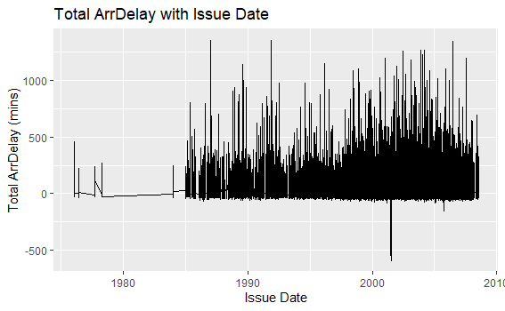

```r
# Total Sum of Delay by issue_date
ggplot(data = df_q2, aes(x=issue_date, y=ArrDelay))+
  geom_line() + ggtitle("Total ArrDelay with Issue Date") +
  xlab("Issue Date") + ylab("Total ArrDelay (mins)")
```

From the graph, we can see three peak points around year 1986, 2000 and 2004. Hence, we proceed to check with the mean value.

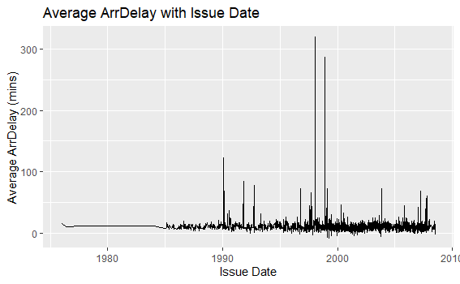

```r
# Average of ArrDelay by issue_date
df_q2 %>% group_by(issue_date) %>% dplyr::summarize(mean = mean(ArrDelay)) %>%
ggplot(aes(x=issue_date, y=mean))+
  geom_line() + ggtitle("Average ArrDelay with Issue Date") +
  xlab("Issue Date") + ylab("Average ArrDelay (mins)")
```

Based on Issue Date, there seem to be more delay occurrences for planes issued after 1998. Also, the low total minutes delayed between 1976 and 1984 might be attributed to planes older than 24 years being removed owing to maintenance faults, or the airline scheduling them with ample time to avoid delays.

## Distribution of Arr Delay with Issue Year

A new column of issue year and plane age is then extracted from the issue date.

```r
df_q2$issue_year = format(as.Date(df_q2$issue_date, format="%m/%d/%Y"),"%Y")
```

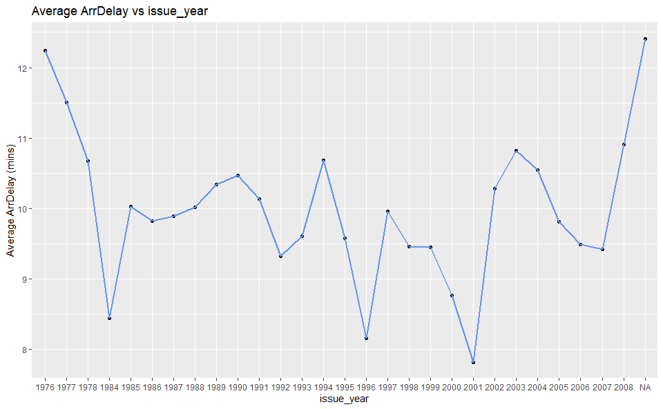

```r
df_q2 %>% group_by(issue_year) %>% dplyr::summarize(mean = mean(ArrDelay)) %>%
  ggplot(aes(x= issue_year, y = mean)) +
  geom_point() +
  geom_line(aes(group = 1), size=1, col = "cornflowerblue") + ggtitle("Average ArrDelay vs issue_year") +
  xlab("issue_year") + ylab("Average ArrDelay (mins)")
```

Further investigations will then be made with Issue Date rather than its Year, as delays became increasingly prevalent after year 2000.

## Comparing Old Planes and Normal Planes

The average age of U.S planes is 11 years, with about 25% of planes above 15 years old (Mayerowitz, 2011).

Hence, we will deem an aircraft to be old when in operation for 15+ years, where data will split into two, with planes issued before 1993 termed old, and those issued 1993 onwards termed normal..

### Distribution of Old & Normal Planes

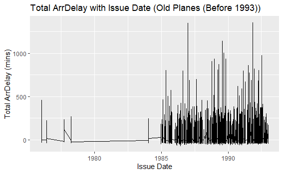

```r
# Plot a subset of older planes
ggplot(data=subset(df_q2, issue_date < as.Date("1993-01-01")),
       aes(x=issue_date, y=ArrDelay))+ geom_line() + ggtitle("Total ArrDelay with Issue Date (Old Planes (Before 1993))") +
  xlab("Issue Date") + ylab("Total ArrDelay (mins)")
```

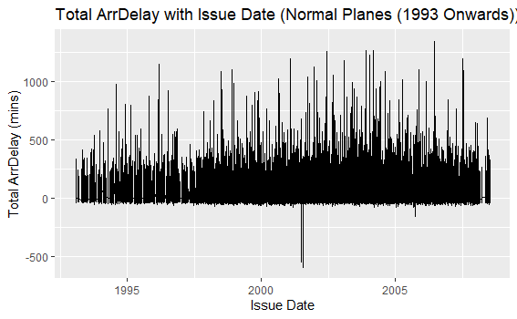

```r
# Plot a subset of normal planes
ggplot(data=subset(df_q2, issue_date > as.Date("1992-12-31")),
       aes(x=issue_date, y=ArrDelay))+ geom_line() + ggtitle("Total ArrDelay with Issue Date (Normal Planes (1993 Onwards))") +
  xlab("Issue Date") + ylab("Total ArrDelay (mins)")
```

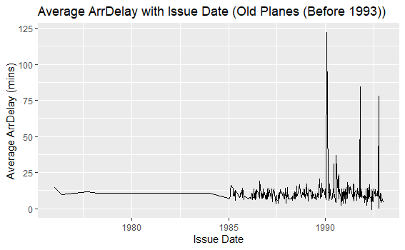

```r
# Plot Average ArrDelay of older planes
ggplot(data=subset(df_q2, issue_date < as.Date("1993-01-01")),
       aes(x=issue_date, y=ArrDelay))+  stat_summary(aes(y = ArrDelay,group=1), fun=mean, geom="line",group=1) + ggtitle("Average ArrDelay with Issue Date (Old Planes (Before 1993))") +
  xlab("Issue Date") + ylab("Average ArrDelay (mins)")
```

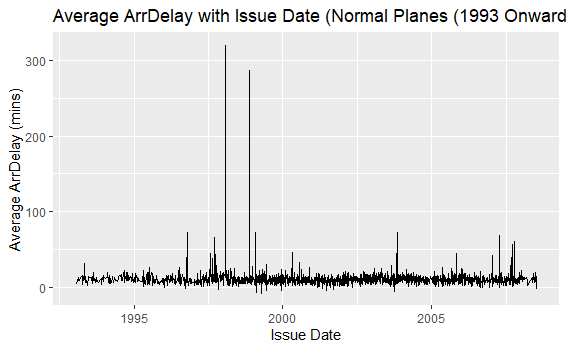

```r
# Plot Average ArrDelay of Normal planes
ggplot(data=subset(df_q2, issue_date > as.Date("1992-12-31")),
       aes(x=issue_date, y=ArrDelay))+  stat_summary(aes(y = ArrDelay,group=1), fun=mean, geom="line",group=1) + ggtitle("Average ArrDelay with Issue Date (Normal Planes (1993 Onwards))") +
  xlab("Issue Date") + ylab("Average ArrDelay (mins)")
```

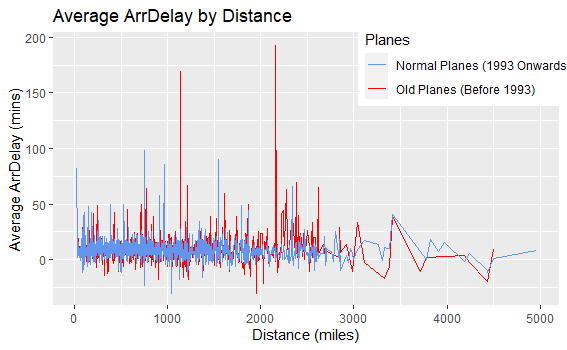

```r
# Plot Average ArrDelay by Distance of Old/Normal planes
ggplot() +  stat_summary(data=subset(df_q2, issue_date < as.Date("1993-01-01")), aes(x=Distance, y = ArrDelay,group=1, color = 'red'), fun=mean, geom="line",group=1, size=0.5) +  stat_summary(data=subset(df_q2, issue_date  > as.Date("1992-12-31")), aes(x=Distance, y = ArrDelay,group=1, color = 'cornflowerblue'), fun=mean, geom="line",group=1, size=0.5) + ggtitle("Average ArrDelay by Distance") +
  xlab("Distance (miles)") + ylab("Average ArrDelay (mins)") +
    scale_colour_manual(name = 'Planes',
         values =c('cornflowerblue'='cornflowerblue','red'='red'), labels = c('Normal Planes (1993 Onwards)','Old Planes (Before 1993)'))+ theme(legend.position = c(0.82,0.88))
```

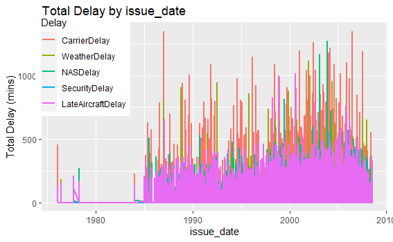

```r
library(reshape2)
# Organizing data
df_q2a <- df_q2 %>% select(issue_date, CarrierDelay, WeatherDelay, NASDelay, SecurityDelay, LateAircraftDelay)
df_q2a <- melt(df_q2a ,  id.vars = 'issue_date', variable.name = 'Delay')
# Plot Total Individual Delays for full data
ggplot(df_q2a, aes(issue_date, value)) +
  geom_line(aes(colour = Delay),size=0.8) + ggtitle("Total Delay by issue_date") +
  xlab("issue_date") + ylab("Total Delay (mins)")+ theme(legend.position = c(0.12,0.78))
```

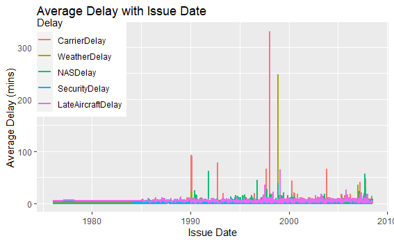

```r
# Organizing data
df_q2a <- df_q2 %>% select(issue_date, CarrierDelay, WeatherDelay, NASDelay, SecurityDelay, LateAircraftDelay)
df_q2a <- melt(df_q2a ,  id.vars = 'issue_date', variable.name = 'Delay')
# Plot Average Individual Delays for full data
ggplot(data=df_q2a,
       aes(x=issue_date, y=value))+  stat_summary(aes(y = value,group=1,colour = Delay), fun=mean, geom="line",group=1, size=1) + ggtitle("Average Delay with Issue Date") +
  xlab("Issue Date") + ylab("Average Delay (mins)") + theme(legend.position = c(0.12,0.78))
```

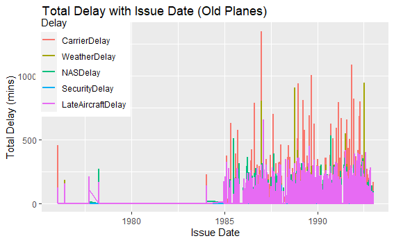

```r
# Organizing data
df_q2a <- df_q2 %>% select(issue_date, CarrierDelay, WeatherDelay, NASDelay, SecurityDelay, LateAircraftDelay)
df_q2a <- melt(df_q2a ,  id.vars = 'issue_date', variable.name = 'Delay')
# Plot Total Individual Delays for old planes
ggplot(data=subset(df_q2a, issue_date < as.Date("1993-01-01")),
       aes(x=issue_date, y=value))+ geom_line(aes(colour = Delay),size=1) + ggtitle("Total Delay with Issue Date (Old Planes)") +
  xlab("Issue Date") + ylab("Total Delay (mins)") + theme(legend.position = c(0.12,0.78))
```

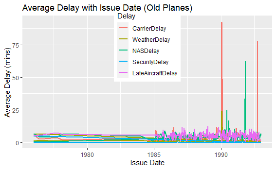

```r
# Organizing data
df_q2a <- df_q2 %>% select(issue_date, CarrierDelay, WeatherDelay, NASDelay, SecurityDelay, LateAircraftDelay)
df_q2a <- melt(df_q2a ,  id.vars = 'issue_date', variable.name = 'Delay')
# Plot Average Individual Delays for old planes
ggplot(data=subset(df_q2a, issue_date < as.Date("1993-01-01")),
       aes(x=issue_date, y=value))+  stat_summary(aes(y = value,group=1,colour = Delay), fun=mean, geom="line",group=1, size=1) + ggtitle("Average Delay with Issue Date (Old Planes)") +
  xlab("Issue Date") + ylab("Average Delay (mins)")  + theme(legend.position = c(0.5,0.78))
```

Old Planes issued around 1990 are more likely to have delays due CarrierDelay, which includes maintainence etc.

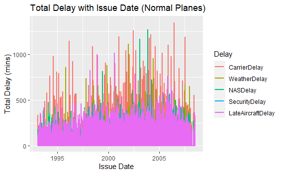

```r
# Organizing data
df_q2a <- df_q2 %>% select(issue_date, CarrierDelay, WeatherDelay, NASDelay, SecurityDelay, LateAircraftDelay)
df_q2a <- melt(df_q2a ,  id.vars = 'issue_date', variable.name = 'Delay')
# Plot Total Individual Delays for normal planes
ggplot(data=subset(df_q2a, issue_date > as.Date("1992-12-31")),
       aes(x=issue_date, y=value))+ geom_line(aes(colour = Delay),size=1) + ggtitle("Total Delay with Issue Date (Normal Planes)") +
  xlab("Issue Date") + ylab("Total Delay (mins)")
```

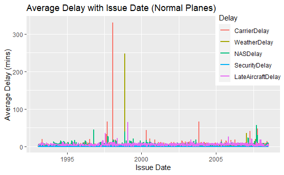

```r
# Organizing data
df_q2a <- df_q2 %>% select(issue_date, CarrierDelay, WeatherDelay, NASDelay, SecurityDelay, LateAircraftDelay)
df_q2a <- melt(df_q2a ,  id.vars = 'issue_date', variable.name = 'Delay')
# Plot Average Individual Delays for normal planes
ggplot(data=subset(df_q2a, issue_date  > as.Date("1992-12-31")),
       aes(x=issue_date, y=value))+  stat_summary(aes(y = value,group=1,colour = Delay), fun=mean, geom="line",group=1, size =1) + ggtitle("Average Delay with Issue Date (Normal Planes)") +
  xlab("Issue Date") + ylab("Average Delay (mins)") + theme(legend.position = c(0.88,0.77))
```

Normal Planes are likely to have CarrierDelays as well.

### Distance Distribution of Old & Normal Planes

Distance is then used to check the delays that Old and Normal Planes will have with respect to the number of miles that they have travelled.

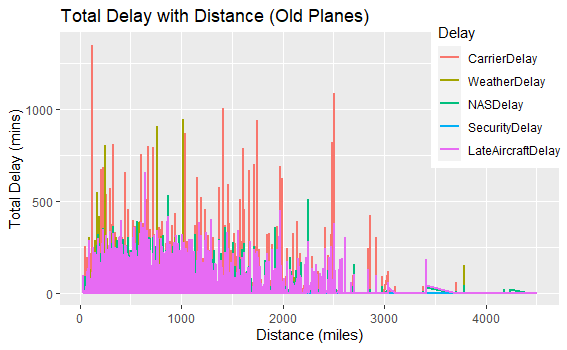

```r
# Organizing data
old_planes=subset(df_q2, issue_date < as.Date("1993-01-01"))
old_planes <- old_planes %>% select(Distance, CarrierDelay, WeatherDelay, NASDelay, SecurityDelay, LateAircraftDelay)
df_q2a <- melt(old_planes,  id.vars = 'Distance', variable.name = 'Delay')
# Plot Total Individual Delays by Distance for Old planes
ggplot(data = df_q2a,
       aes(x=Distance, y=value))+ geom_line(aes(colour = Delay),size=1) + ggtitle("Total Delay with Distance (Old Planes)") +
  xlab("Distance (miles)") + ylab("Total Delay (mins)") + theme(legend.position = c(0.88,0.78))
```

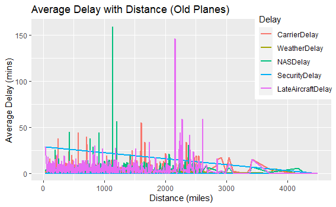

```r
# Organizing data
old_planes=subset(df_q2, issue_date < as.Date("1993-01-01"))
old_planes <- old_planes %>% select(Distance, CarrierDelay, WeatherDelay, NASDelay, SecurityDelay, LateAircraftDelay)
df_q2a <- melt(old_planes,  id.vars = 'Distance', variable.name = 'Delay')
# Plot Average Individual Delays by Distance for Old planes
ggplot(data = df_q2a,
       aes(x=Distance, y=value))+  stat_summary(aes(y = value,group=1,colour = Delay), fun=mean, geom="line",group=1,size=1)+ ggtitle("Average Delay with Distance (Old Planes)") +
  xlab("Distance (miles)") + ylab("Average Delay (mins)") + theme(legend.position = c(0.88,0.78))
```

In R, although the LateAircraftDelay and NASDelay have higher average values, Carrier Delays also have occurrences of average delay ranging around 50 minutes at 1500 miles.

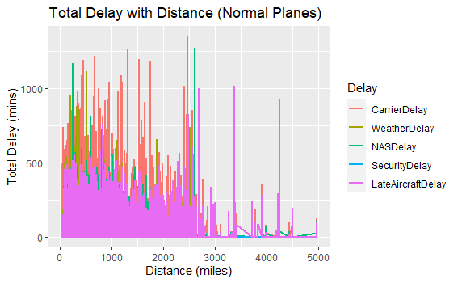

```r
# Organizing data
normal_planes=subset(df_q2, issue_date > as.Date("1992-12-31"))
normal_planes <- normal_planes %>% select(Distance, CarrierDelay, WeatherDelay, NASDelay, SecurityDelay, LateAircraftDelay)
df_q2a <- melt(normal_planes,  id.vars = 'Distance', variable.name = 'Delay')
# Plot Total Individual Delays by Distance for Normal planes
ggplot(data = df_q2a,
       aes(x=Distance, y=value))+ geom_line(aes(colour = Delay),size=1) + ggtitle("Total Delay with Distance (Normal Planes)") +
  xlab("Distance (miles)") + ylab("Total Delay (mins)")
```

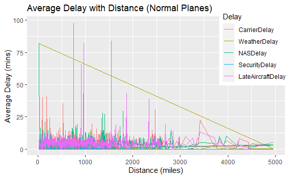

```r
# Organizing data
normal_planes=subset(df_q2, issue_date > as.Date("1992-12-31"))
normal_planes <- normal_planes %>% select(Distance, CarrierDelay, WeatherDelay, NASDelay, SecurityDelay, LateAircraftDelay)
df_q2a <- melt(normal_planes,  id.vars = 'Distance', variable.name = 'Delay')
# Plot Average Individual Delays by Distance for Normal planes
ggplot(data = df_q2a,
       aes(x=Distance, y=value))+  stat_summary(aes(y = value,group=1,colour = Delay), fun=mean, geom="line",group=1)+ ggtitle("Average Delay with Distance (Normal Planes)") +
  xlab("Distance (miles)") + ylab("Average Delay (mins)") + theme(legend.position = c(0.88,0.78))
```

Overall, the grouping by Issue Year was clear in showing that older planes do suffer from more delay, but only by up to 8 minutes on average, where LateAircraftDelay, followed by Carrier/NASDelay are the primary causes.

When utilized for long-haul flights, older planes are also more likely to have delays due to carrier delays that might have resulted from aircraft maintenance or inspection.

The difference in delay however is quite negligible and it might be due to airlines “padding” and scheduling extra time for flights to prevent flights from being classified as delayed (Kramer, 2019).

```r
# To save up space
rm(df_q2)
rm(df_q2a)
rm(counts)
rm(normal_planes)
rm(old_planes)
```